# Scatterplot Hatching Function

Tejas Guha

August 29, 2020

## Introduction

The objective of this function is to efficiently create unique patterns for different groups in a scatterplot so that if the groups were colored the same, they would be distinguishable. Thus, this function would be useful in making scatterplot visualizations more accessible to those with visual impairments such as color blindness. The data that will be used to showcase the function is [a tissue-CyCIF PDAC dataset from Lin et al](http://spatial.rc.fas.harvard.edu/spatialgiotto/giotto.cycif.html). Here is a look at the dataset after some preprocessing.

```
        Xt        Yt location
1 1342.878  -801.154 Pancreas
2 5688.494 -1391.393 Pancreas
3 6295.826 -1393.807 Pancreas
4 5344.257 -1391.650 Pancreas
5 5640.034 -1391.416 Pancreas
6 5923.357 -1390.776 Pancreas
```

## How to Use it

To create a hatched scatterplot, use `scatterHatch()` which takes the following arguments:

[output not shown]

Here's a plot of the PDAC dataset with the default settings:

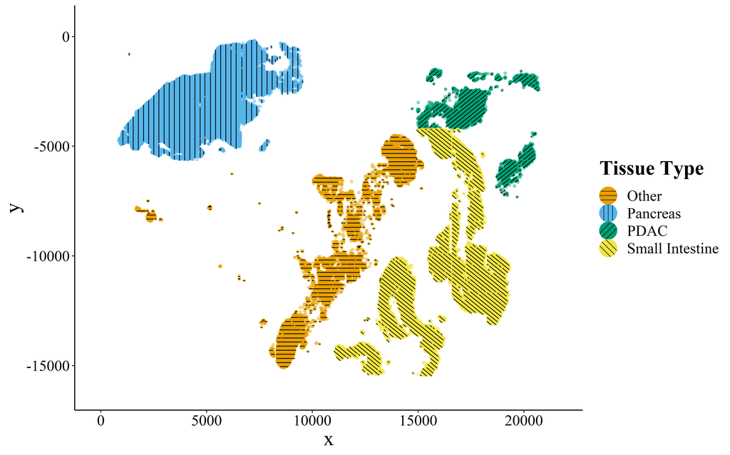

```r
plt <- scatterHatch(sampleDF, sampleDF$Xt, sampleDF$Yt, as.factor(sampleDF$location),
    "Tissue Type", 1) + myTheme
plot(plt)
```

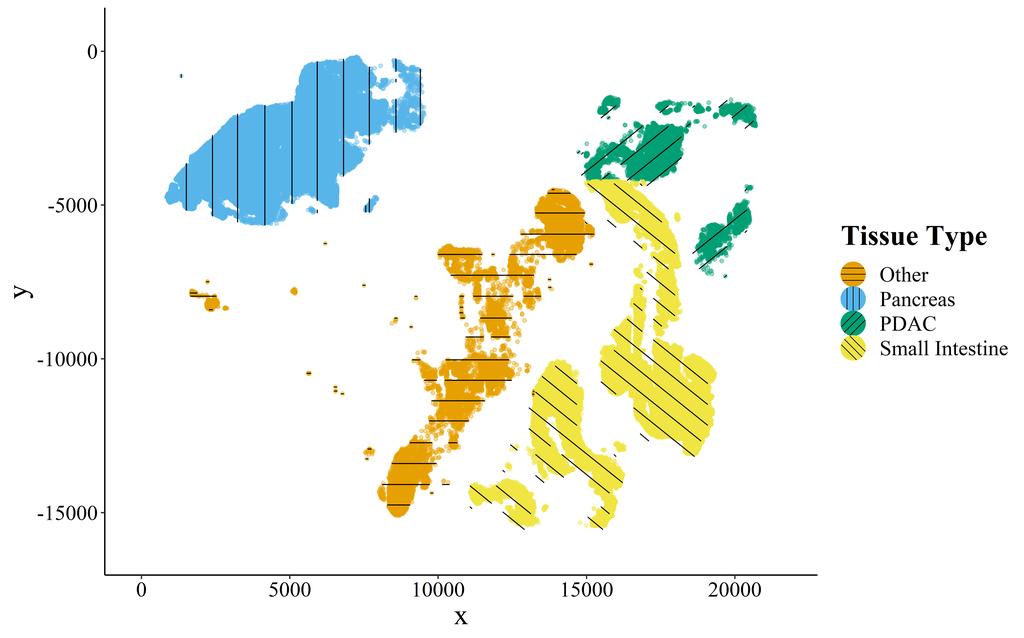

```r
plt <- scatterHatch(sampleDF, sampleDF$Xt, sampleDF$Yt, as.factor(sampleDF$location),
    "Tissue Type", 1, gridSize = 100) + myTheme
plot(plt)
```

### Controlling the Pattern Aesthetics

There are many characteristics of each pattern that can be controlled by the user. These characteristics are passed into a list in the patternList argument of `scatterHatch()`.

[output not shown]

To make the positiveDiagonal pattern have red lines and the vertical pattern have dotted lines:

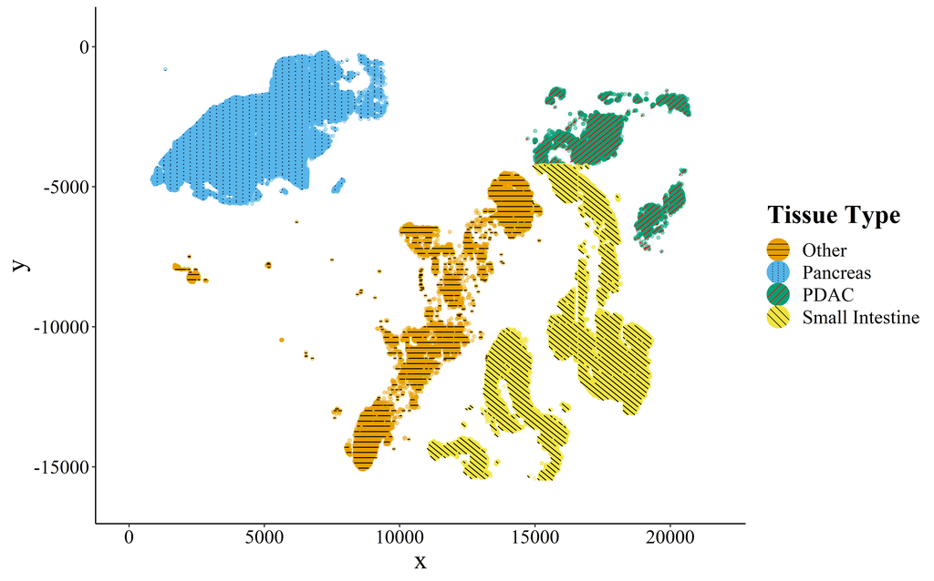

```r
patternList = list(list(pattern = "positiveDiagonal", lineColor = "red"), list(pattern = "vertical",
    lineType = "dotted"))
plt <- scatterHatch(sampleDF, sampleDF$Xt, sampleDF$Yt, as.factor(sampleDF$location),
    "Tissue Type", 1, patternList = patternList) + myTheme
plot(plt)
```

Having all the patterns in the list changes the ordering of the patterns assigned for each group.

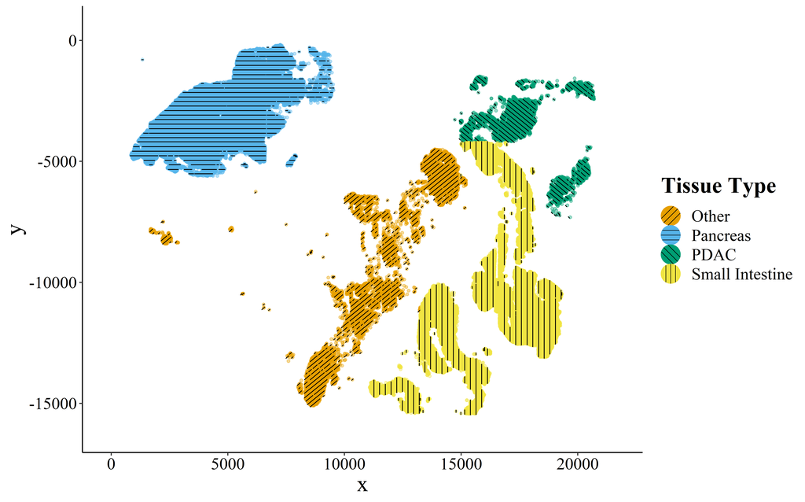

```r
patternList = list(list(pattern = "positiveDiagonal"), list(pattern = "horizontal"),
    list(pattern = "negativeDiagonal"), list(pattern = "vertical"))
plt <- scatterHatch(sampleDF, sampleDF$Xt, sampleDF$Yt, as.factor(sampleDF$location),
    "Tissue Type", 1, patternList = patternList) + myTheme
plot(plt)
```

To get a closer look at how the sparsity value works, let's look at the "Other" tissue sample. Here the sparsity has a value of 300.

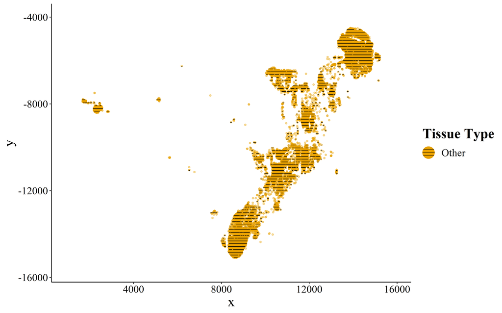

Notice how decreasing the sparsity value to 5 renders the patterns on some of the more isolated points.

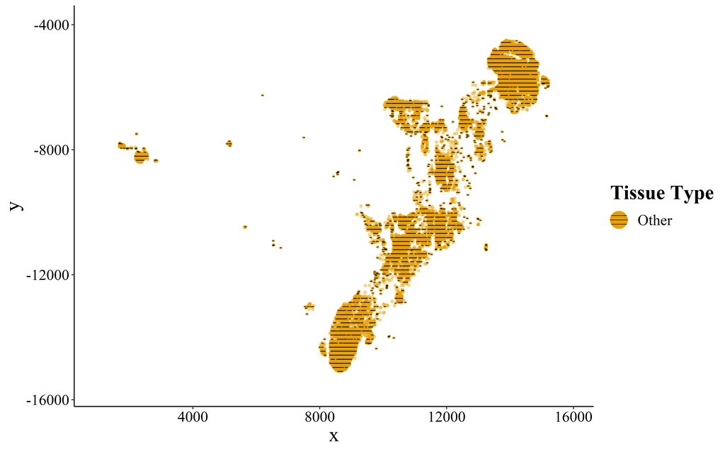